# Statistical Analyses

David John Baker

19/03/2021

This markdown contains the analysis for “The Perceptual Attraction of Predominant Chords”. It attempts to more clearly link the theoretical introduction to the statistical modeling to the discussion.

The document is meant to serve as a reference to be pasted into the manuscript. All code to create tables, charts, and statistical analyses are found here.

> This was last updated on March, 19th 2021 after a second R&R

## Hypotheses and Analyses

### Supervised

1. Top Down Model: We predict category of predominant will predict attraction ratings globally.
- Chromatic most attracted
- Diatonic second
- Bridge third
- Non PD last
- **Follow up with pairwise comparisons**
2. We predict musical training will lead to qualitative difference in ratings (interaction/random slopes)
3. We predict feature analysis will help structure what it is about chords that leads to differences in ratings

### Unsupervised

Following our regressionthe modeling of these five musical features, a final analysis using unsupervised machine learning methods to explore participant response strategies(James et al. 2013). Mirroring our above strategy to take both a bottom up and top down approach to our perceptual data using supervised methods, we also employ a top down and bottom up analysis using unsupervised methods.

We first decompose the empirical response data from our experiment using principal component analysis (PCA); this analysis serves as our top down method of understanding listener response strategies.

Secondly, we submit the features used in our feature-based regression model to a hierarchical agglomerative clustering algorithm to consider novel ways the pre-dominant category might be re-conceptualized.

## Descriptives

```r
df %>%
  select(participant, group, i_have_had_formal_training_in_music_theory_for_years) %>%
  distinct() %>%
  group_by(group) %>%
  summarise(mean_theory = mean(i_have_had_formal_training_in_music_theory_for_years),
            sd_theory = sd(i_have_had_formal_training_in_music_theory_for_years))
```

```
## # A tibble: 3 x 3
##   group      mean_theory sd_theory
## * <chr>            <dbl>     <dbl>
## 1 freshman          3.62     1.88
## 2 prolific          2.25     1.74
## 3 upperclass        5.17     0.985
```

## Results

### Supervised

First we check for test-restest reliability then collapse data based on R1F = 0.92 Reliability of average of all items for one time (Random time effects) and RkF = 0.96 Reliability of average of all items and both times (Fixed time effects).

```r
# Check test-retest with psych package
response_data %>%
  select(block,I:`viio7/V`) %>%
  rename(time = block) %>%
  data.frame() %>%
  testRetest()
```

```
## boundary (singular) fit: see ?isSingular
```

```
##
## Test Retest reliability
## Call: testRetest(t1 = .)
##
## Number of subjects =  59  Number of items =  31
##  Correlation of scale scores over time 0.77
##  Alpha reliability statistics for time 1 and time 2
##        raw G3 std G3   G6 av.r   S/N   se lower upper var.r
## Time 1   0.90   0.90 0.96 0.22  8.82 0.02  0.57  0.96  0.03
## Time 2   0.91   0.91 0.97 0.26 10.67 0.02  0.62  0.95  0.03
##
##  Mean between person, across item reliability =  0.46
##  Mean within person, across item reliability =  0.35
## with standard deviation of  0.26
##
##  Mean within person, across item d2 =  2.41
## R1F  =  0.92 Reliability of average of all items for one  time (Random time effects)
## RkF  =  0.96 Reliability of average of all items and both times (Fixed time effects)
## R1R  =  0.4 Generalizability of a single time point across all items (Random time effects)
## Rc   =  0.94 Generalizability of change (fixed time points, fixed items)
## Multilevel components of variance
##              variance Percent
## ID               0.42    0.18
## Time             0.00    0.00
## Items            0.13    0.05
## ID x time        0.60    0.25
## ID x items       0.10    0.04
## time x items     0.03    0.01
## Residual         1.08    0.46
## Total            2.35    1.00
##
##  To see the item.stats, print with short=FALSE.
## To see the subject reliabilities and differences, examine the 'scores' object.
```

```r
# Reduce df to variables for modeling
model_data <- df %>%
  select(rating,
         chord,
         chord_family,
         lerdhal_tension,
         parncut_roughness,
         semitone_voice_move,
         rootmotion,
         number_tendency_tones4_6,
         participant,
         block,
         i_have_had_formal_training_in_music_theory_for_years,
         f3_musical_training,
         experimental_group) %>%
  mutate(experimental_group = str_replace_all(experimental_group, pattern = "freshman",replacement = "freshmen")) %>%
  mutate(experimental_group = str_replace_all(experimental_group, pattern = "upperclass",replacement = "Juniors/Seniors")) %>%
  mutate(experimental_group = factor(experimental_group, c("Juniors/Seniors","freshmen", "prolific"))) %>%
  mutate(chord_family_f = factor("non_pd","bridge","common_pd","chromatic"))

# Test retest, OK, collapse to one average rating per participant
model_data %>%
  group_by(chord, participant) %>%
  summarise(mean_rating = mean(rating)) -> summary_ratings
model_data %>%
  select(chord, chord_family, lerdhal_tension:participant, i_have_had_formal_training_in_music_theory_for_years, f3_musical_training, experimental_group) %>%
  left_join(summary_ratings) -> collapsed_model
```

## Regression Analyses

We now run each hypothesis as linear, mixed effects regression model. We note here that [ANOVA models are a special case of regression](https://lindeloev.github.io/tests-as-linear/) and that running a linear mixed effects model with a random effect of participant is [analgous to running a within subjects repeated measures ANOVA in R](https://m-clark.github.io/docs/mixedModels/anovamixed.html).

### Chord Category Model

```r
# CHORD CATEGORY
# RM-ANOVA as LINEAR MIXED EFFECTS
chord_cat_rm <- lmer(mean_rating ~ chord_family + (1|participant), data = collapsed_model)

# Model Summary Output
summary(chord_cat_rm)
```

```
## Linear mixed model fit by REML. t-tests use Satterthwaite's method [
## lmerModLmerTest]
## Formula: mean_rating ~ chord_family + (1 | participant)
##    Data: collapsed_model
##
## REML criterion at convergence: 11265.3
##
## Scaled residuals:
##     Min      1Q  Median      3Q     Max
## -3.8823 -0.6102  0.0582  0.7069  3.2918
##
## Random effects:
##  Groups      Name        Variance Std.Dev.
##  participant (Intercept) 0.4864   0.6974
##  Residual                1.2043   1.0974
## Number of obs: 3658, groups:  participant, 59
##
## Fixed effects:
##                           Estimate Std. Error        df t value Pr(>|t|)
## (Intercept)              4.395e+00  9.757e-02 7.150e+01  45.046   <2e-16 ***
## chord_familychromatic_pd 4.181e-01  5.051e-02 3.596e+03   8.277   <2e-16 ***
## chord_familycommon_pd    5.290e-01  5.051e-02 3.596e+03  10.472   <2e-16 ***
## chord_familynot_pd       3.238e-02  5.229e-02 3.596e+03   0.619    0.536
## ---
## Signif. codes:  0 '***' 0.001 '**' 0.01 '*' 0.05 '.' 0.1 ' ' 1
##
## Correlation of Fixed Effects:
##              (Intr) chrd_fmlych_ chrd_fmlycm_
## chrd_fmlych_ -0.259
## chrd_fmlycm_ -0.259  0.500
## chrd_fmlyn_  -0.250  0.483        0.483
```

```r
anova(chord_cat_rm)
```

```
## Type III Analysis of Variance Table with Satterthwaite's method
##              Sum Sq Mean Sq NumDF DenDF F value    Pr(>F)
## chord_family 198.25  66.083     3  3596  54.872 < 2.2e-16 ***
## ---
## Signif. codes:  0 '***' 0.001 '**' 0.01 '*' 0.05 '.' 0.1 ' ' 1
```

```r
r.squaredGLMM(chord_cat_rm)
```

```
##             R2m       R2c
## [1,] 0.03106759 0.3098197
```

```r
options(scipen = 999)
summary(chord_cat_rm, ddf = "Satterthwaite")
```

```
## Linear mixed model fit by REML. t-tests use Satterthwaite's method [
## lmerModLmerTest]
## Formula: mean_rating ~ chord_family + (1 | participant)
##    Data: collapsed_model
##
## REML criterion at convergence: 11265.3
##
## Scaled residuals:
##     Min      1Q  Median      3Q     Max
## -3.8823 -0.6102  0.0582  0.7069  3.2918
##
## Random effects:
##  Groups      Name        Variance Std.Dev.
##  participant (Intercept) 0.4864   0.6974
##  Residual                1.2043   1.0974
## Number of obs: 3658, groups:  participant, 59
##
## Fixed effects:
##                            Estimate Std. Error         df t value
## (Intercept)                 4.39518    0.09757   71.49974  45.046
## chord_familychromatic_pd    0.41810    0.05051 3596.00001   8.277
## chord_familycommon_pd       0.52897    0.05051 3596.00001  10.472
## chord_familynot_pd          0.03238    0.05229 3596.00001   0.619
##                                     Pr(>|t|)
## (Intercept)              <0.0000000000000002 ***
## chord_familychromatic_pd <0.0000000000000002 ***
## chord_familycommon_pd    <0.0000000000000002 ***
## chord_familynot_pd                     0.536
## ---
## Signif. codes:  0 '***' 0.001 '**' 0.01 '*' 0.05 '.' 0.1 ' ' 1
##
## Correlation of Fixed Effects:
##              (Intr) chrd_fmlych_ chrd_fmlycm_
## chrd_fmlych_ -0.259
## chrd_fmlycm_ -0.259  0.500
## chrd_fmlyn_  -0.250  0.483        0.483
```

```r
# Post Hoc Comparisions
glht(chord_cat_rm, mcp(chord_family="Tukey")) %>% summary()
```

```
##
##   Simultaneous Tests for General Linear Hypotheses
##
## Multiple Comparisons of Means: Tukey Contrasts
##
##
## Fit: lmer(formula = mean_rating ~ chord_family + (1 | participant),
##     data = collapsed_model)
##
## Linear Hypotheses:
##                                   Estimate Std. Error z value Pr(>|z|)
## chromatic_pd - bridge_chords == 0  0.41810    0.05051   8.277   <0.001 ***
## common_pd - bridge_chords == 0     0.52897    0.05051  10.472   <0.001 ***
## not_pd - bridge_chords == 0        0.03238    0.05229   0.619    0.926
## common_pd - chromatic_pd == 0      0.11087    0.05051   2.195    0.125
## not_pd - chromatic_pd == 0        -0.38572    0.05229  -7.377   <0.001 ***
## not_pd - common_pd == 0           -0.49659    0.05229  -9.498   <0.001 ***
## ---
## Signif. codes:  0 '***' 0.001 '**' 0.01 '*' 0.05 '.' 0.1 ' ' 1
## (Adjusted p values reported -- single-step method)
```

#### Figure For Chord Category Model

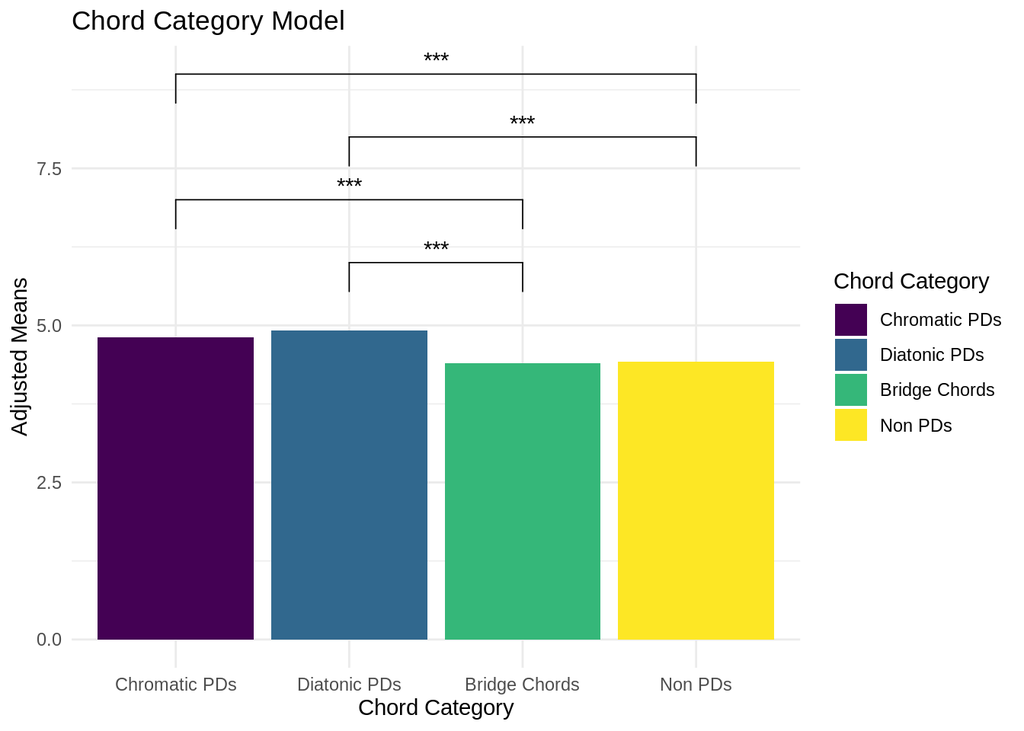

```r
means_a <- tibble(means = c(4.39518,4.39518+.41810,4.39518+.52897,4.39518+.03238),
                std_errors = c(.09757,.05051,.05051, .05229),
                labz = c("Bridge Chords","Chromatic PDs","Diatonic PDs","Non PDs"))


means_a %>%
  mutate(labz = factor(labz,
                       levels = c("Chromatic PDs","Diatonic PDs","Bridge Chords", "Non PDs"))) %>%
  ggplot(aes(y = means, x = labz, fill = labz)) +
  geom_bar(stat = "identity") +
#  geom_errorbar(aes(ymin = means - std_errors, ymax = means+std_errors)) +
  labs(x = "Chord Category", y = "Adjusted Means", title = "Chord Category Model", fill = "Chord Category") +
  scale_fill_viridis(discrete = TRUE) +
  geom_bracket(inherit.aes = FALSE, xmin = c("Bridge Chords","Bridge Chords", "Non PDs","Non PDs"),
  xmax = c("Chromatic PDs","Diatonic PDs","Chromatic PDs","Diatonic PDs"),
   y.position = c(7, 6, 9 , 8),
   label = c("***"),
   tip.length = 0.1) +
  theme_minimal()  -> analysis_a_plot_1

analysis_a_plot_1
```

```r
# Same analysis, run with base R calculations
#chord_cat_rm_anova <- aov(mean_rating ~ chord_family + Error(participant), data = collapsed_model)
#summary(chord_cat_rm_anova)
```

### Musical Training Model

```r
# MUSICAL TRAINING
# Run as Linear Mixed Effects
# Main Effects: Theory Training and Chord Category
# Interaction
# Participant as Random Effects, within subject


musical_training_rm <- lmer(mean_rating ~ chord_family*i_have_had_formal_training_in_music_theory_for_years  + (1|participant),
                            data = collapsed_model)
summary(musical_training_rm)
```

```
## Linear mixed model fit by REML. t-tests use Satterthwaite's method [
## lmerModLmerTest]
## Formula:
## mean_rating ~ chord_family * i_have_had_formal_training_in_music_theory_for_years +
##     (1 | participant)
##    Data: collapsed_model
##
## REML criterion at convergence: 11234.9
##
## Scaled residuals:
##     Min      1Q  Median      3Q     Max
## -3.7153 -0.6247  0.0612  0.6804  3.3735
##
## Random effects:
##  Groups      Name        Variance Std.Dev.
##  participant (Intercept) 0.4878   0.6984
##  Residual                1.1884   1.0901
## Number of obs: 3658, groups:  participant, 59
##
## Fixed effects:
##                                                                                 Estimate
## (Intercept)                                                                      4.56287
## chord_familychromatic_pd                                                        -0.22808
## chord_familycommon_pd                                                            0.11866
## chord_familynot_pd                                                              -0.21436
## i_have_had_formal_training_in_music_theory_for_years                            -0.04623
## chord_familychromatic_pd:i_have_had_formal_training_in_music_theory_for_years    0.17815
## chord_familycommon_pd:i_have_had_formal_training_in_music_theory_for_years       0.11312
## chord_familynot_pd:i_have_had_formal_training_in_music_theory_for_years          0.06803
##                                                                               Std. Error
## (Intercept)                                                                      0.20560
## chord_familychromatic_pd                                                         0.10570
## chord_familycommon_pd                                                            0.10570
## chord_familynot_pd                                                               0.10941
## i_have_had_formal_training_in_music_theory_for_years                             0.04989
## chord_familychromatic_pd:i_have_had_formal_training_in_music_theory_for_years    0.02565
## chord_familycommon_pd:i_have_had_formal_training_in_music_theory_for_years       0.02565
## chord_familynot_pd:i_have_had_formal_training_in_music_theory_for_years          0.02655
##                                                                                       df
## (Intercept)                                                                     70.05321
```

[output cut: 39 more lines]

```
## chrd_fmlych_           -0.257
## chrd_fmlycm_           -0.257  0.500
## chrd_fmlyn_            -0.248  0.483        0.483
## i_h________            -0.880  0.226        0.226        0.219
## chrd_fmlych_:_________  0.226 -0.880       -0.440       -0.425      -0.257
## chrd_fmlycm_:_________  0.226 -0.440       -0.880       -0.425      -0.257
## chrd_fmlyn_:_________   0.219 -0.425       -0.425       -0.880      -0.248
##                        chrd_fmlych_:_________ chrd_fmlycm_:_________
## chrd_fmlych_
## chrd_fmlycm_
## chrd_fmlyn_
## i_h________
## chrd_fmlych_:_________
## chrd_fmlycm_:_________  0.500
## chrd_fmlyn_:_________   0.483                  0.483
```

```r
anova(musical_training_rm)
```

```
## Type III Analysis of Variance Table with Satterthwaite's method
##                                                                   Sum Sq
## chord_family                                                      17.772
## i_have_had_formal_training_in_music_theory_for_years               1.006
## chord_family:i_have_had_formal_training_in_music_theory_for_years 60.791
##                                                                   Mean Sq NumDF
## chord_family                                                       5.9240     3
## i_have_had_formal_training_in_music_theory_for_years               1.0058     1
## chord_family:i_have_had_formal_training_in_music_theory_for_years 20.2637     3
##                                                                   DenDF F value
## chord_family                                                       3593  4.9848
## i_have_had_formal_training_in_music_theory_for_years                 57  0.8463
## chord_family:i_have_had_formal_training_in_music_theory_for_years  3593 17.0511
##                                                                             Pr(>F)
## chord_family                                                              0.001881
## i_have_had_formal_training_in_music_theory_for_years                      0.361467
## chord_family:i_have_had_formal_training_in_music_theory_for_years 0.00000000005397
##
## chord_family                                                      **
## i_have_had_formal_training_in_music_theory_for_years
## chord_family:i_have_had_formal_training_in_music_theory_for_years ***
## ---
## Signif. codes:  0 '***' 0.001 '**' 0.01 '*' 0.05 '.' 0.1 ' ' 1
```

```r
r.squaredGLMM(musical_training_rm)
```

```
##            R2m       R2c
## [1,] 0.0446536 0.3226579
```

```r
summary(musical_training_rm, ddf = "Satterthwaite")
```

```
## Linear mixed model fit by REML. t-tests use Satterthwaite's method [
## lmerModLmerTest]
## Formula:
## mean_rating ~ chord_family * i_have_had_formal_training_in_music_theory_for_years +
##     (1 | participant)
##    Data: collapsed_model
##
## REML criterion at convergence: 11234.9
##
## Scaled residuals:
##     Min      1Q  Median      3Q     Max
## -3.7153 -0.6247  0.0612  0.6804  3.3735
##
## Random effects:
##  Groups      Name        Variance Std.Dev.
##  participant (Intercept) 0.4878   0.6984
##  Residual                1.1884   1.0901
## Number of obs: 3658, groups:  participant, 59
##
## Fixed effects:
##                                                                                 Estimate
## (Intercept)                                                                      4.56287
## chord_familychromatic_pd                                                        -0.22808
## chord_familycommon_pd                                                            0.11866
## chord_familynot_pd                                                              -0.21436
## i_have_had_formal_training_in_music_theory_for_years                            -0.04623
## chord_familychromatic_pd:i_have_had_formal_training_in_music_theory_for_years    0.17815
## chord_familycommon_pd:i_have_had_formal_training_in_music_theory_for_years       0.11312
## chord_familynot_pd:i_have_had_formal_training_in_music_theory_for_years          0.06803
##                                                                               Std. Error
## (Intercept)                                                                      0.20560
## chord_familychromatic_pd                                                         0.10570
## chord_familycommon_pd                                                            0.10570
## chord_familynot_pd                                                               0.10941
## i_have_had_formal_training_in_music_theory_for_years                             0.04989
## chord_familychromatic_pd:i_have_had_formal_training_in_music_theory_for_years    0.02565
## chord_familycommon_pd:i_have_had_formal_training_in_music_theory_for_years       0.02565
## chord_familynot_pd:i_have_had_formal_training_in_music_theory_for_years          0.02655
##                                                                                       df
## (Intercept)                                                                     70.05321
```

[output cut: 39 more lines]

```
## chrd_fmlych_           -0.257
## chrd_fmlycm_           -0.257  0.500
## chrd_fmlyn_            -0.248  0.483        0.483
## i_h________            -0.880  0.226        0.226        0.219
## chrd_fmlych_:_________  0.226 -0.880       -0.440       -0.425      -0.257
## chrd_fmlycm_:_________  0.226 -0.440       -0.880       -0.425      -0.257
## chrd_fmlyn_:_________   0.219 -0.425       -0.425       -0.880      -0.248
##                        chrd_fmlych_:_________ chrd_fmlycm_:_________
## chrd_fmlych_
## chrd_fmlycm_
## chrd_fmlyn_
## i_h________
## chrd_fmlych_:_________
## chrd_fmlycm_:_________  0.500
## chrd_fmlyn_:_________   0.483                  0.483
```

```r
# Done with Musial Training SubScale of GMSI
musical_training_rm_f3 <- lmer(mean_rating ~ chord_family*f3_musical_training  + (1|participant),
                            data = collapsed_model)
summary(musical_training_rm_f3)
```

```
## Linear mixed model fit by REML. t-tests use Satterthwaite's method [
## lmerModLmerTest]
## Formula: mean_rating ~ chord_family * f3_musical_training + (1 | participant)
##    Data: collapsed_model
##
## REML criterion at convergence: 11218
##
## Scaled residuals:
##     Min      1Q  Median      3Q     Max
## -3.9130 -0.6112  0.0426  0.6931  3.3267
##
## Random effects:
##  Groups      Name        Variance Std.Dev.
##  participant (Intercept) 0.4855   0.6968
##  Residual                1.1805   1.0865
## Number of obs: 3658, groups:  participant, 59
##
## Fixed effects:
##                                                 Estimate  Std. Error
## (Intercept)                                     5.004263    0.545449
## chord_familychromatic_pd                       -1.976527    0.280162
## chord_familycommon_pd                          -0.608781    0.280162
## chord_familynot_pd                             -1.043674    0.289995
## f3_musical_training                            -0.021939    0.019331
## chord_familychromatic_pd:f3_musical_training    0.086253    0.009929
## chord_familycommon_pd:f3_musical_training       0.040981    0.009929
## chord_familynot_pd:f3_musical_training          0.038759    0.010278
##                                                       df t value
## (Intercept)                                    70.025258   9.175
## chord_familychromatic_pd                     3592.999995  -7.055
## chord_familycommon_pd                        3592.999999  -2.173
## chord_familynot_pd                           3592.999946  -3.599
## f3_musical_training                            70.025258  -1.135
## chord_familychromatic_pd:f3_musical_training 3592.999994   8.687
## chord_familycommon_pd:f3_musical_training    3592.999998   4.127
## chord_familynot_pd:f3_musical_training       3592.999946   3.771
##                                                          Pr(>|t|)
## (Intercept)                                     0.000000000000126 ***
## chord_familychromatic_pd                        0.000000000002062 ***
## chord_familycommon_pd                                    0.029848 *
```

[output cut: 10 more lines]

```
## chrd_fmlych_     -0.257
## chrd_fmlycm_     -0.257  0.500
## chrd_fmlyn_      -0.248  0.483        0.483
## f3_mscl_trn      -0.984  0.253        0.253        0.244
## chrd_fmlych_:3__  0.253 -0.984       -0.492       -0.475      -0.257
## chrd_fmlycm_:3__  0.253 -0.492       -0.984       -0.475      -0.257
## chrd_fmlyn_:3__   0.244 -0.475       -0.475       -0.984      -0.248
##                  chrd_fmlych_:3__ chrd_fmlycm_:3__
## chrd_fmlych_
## chrd_fmlycm_
## chrd_fmlyn_
## f3_mscl_trn
## chrd_fmlych_:3__
## chrd_fmlycm_:3__  0.500
## chrd_fmlyn_:3__   0.483            0.483
```

```r
anova(musical_training_rm, musical_training_rm_f3)
```

```
## refitting model(s) with ML (instead of REML)
```

```
## Data: collapsed_model
## Models:
## musical_training_rm: mean_rating ~ chord_family * i_have_had_formal_training_in_music_theory_for_years +
## musical_training_rm:     (1 | participant)
## musical_training_rm_f3: mean_rating ~ chord_family * f3_musical_training + (1 | participant)
##                        npar   AIC   BIC  logLik deviance  Chisq Df
## musical_training_rm      10 11218 11280 -5598.8    11198
## musical_training_rm_f3   10 11193 11255 -5586.6    11173 24.443  0
##                                   Pr(>Chisq)
## musical_training_rm
## musical_training_rm_f3 < 0.00000000000000022 ***
## ---
## Signif. codes:  0 '***' 0.001 '**' 0.01 '*' 0.05 '.' 0.1 ' ' 1
```

```r
anova(musical_training_rm_f3)
```

```
## Type III Analysis of Variance Table with Satterthwaite's method
##                                  Sum Sq Mean Sq NumDF DenDF F value
## chord_family                     62.316 20.7720     3  3593 17.5966
## f3_musical_training               1.339  1.3394     1    57  1.1347
## chord_family:f3_musical_training 89.368 29.7893     3  3593 25.2355
##                                                Pr(>F)
## chord_family                     0.000000000024455101 ***
## f3_musical_training                            0.2913
## chord_family:f3_musical_training 0.000000000000000375 ***
## ---
## Signif. codes:  0 '***' 0.001 '**' 0.01 '*' 0.05 '.' 0.1 ' ' 1
```

```r
r.squaredGLMM(musical_training_rm_f3)
```

```
##             R2m       R2c
## [1,] 0.05041191 0.3271564
```

```r
# Also run with base-R
# rm_anova_music <- aov(mean_rating ~ chord_family*i_have_had_formal_training_in_music_theory_for_years + Error(participant), data = collapsed_model)
# summary(rm_anova_music)
```

#### Figure for Musical Training Model

```r
library(ggeffects)

vexta = c("0","0.5","1","2","3","4 - 6","> 7")



#BLACK AND WHITE
ggpredict(musical_training_rm,
          terms = c("i_have_had_formal_training_in_music_theory_for_years", "chord_family"),
          type = "fe") %>%
   plot(ci.style = "ribbon",  alpha = .05) + # colors = "bw",
   labs(x = "I have had formal training in music theory for __ years", y = "Rating",
        title = "Music Theory Training Model") +
   scale_x_continuous(breaks = seq(1,7,1),
                     labels = vexta)  -> rm_musical_plot


rm_musical_plot$data$group
```

```
##  [1] bridge_chords chromatic_pd  common_pd     not_pd        bridge_chords
##  [6] chromatic_pd  common_pd     not_pd        bridge_chords chromatic_pd
## [11] common_pd     not_pd        bridge_chords chromatic_pd  common_pd
## [16] not_pd        bridge_chords chromatic_pd  common_pd     not_pd
## [21] bridge_chords chromatic_pd  common_pd     not_pd        bridge_chords
## [26] chromatic_pd  common_pd     not_pd
## Levels: bridge_chords chromatic_pd common_pd not_pd
```

```r
# For When it's BW
rm_musical_plot$labels$linetype <- "Chord Category"

rm_musical_plot$data$group <- rm_musical_plot$data$group %>% str_replace_all("bridge_chords", "Bridge Chords")
rm_musical_plot$data$group <- rm_musical_plot$data$group %>% str_replace_all("not_pd", "Non predominant")
rm_musical_plot$data$group <- rm_musical_plot$data$group %>% str_replace_all("common_pd", "Diatonic Predominant")
rm_musical_plot$data$group <- rm_musical_plot$data$group %>% str_replace_all("chromatic_pd", "Chromatic Predominant")

# For Color
rm_musical_plot$labels$colour <- "Chord Category"

rm_musical_plot$data$group_col <- rm_musical_plot$data$group_col %>% str_replace_all("bridge_chords", "Bridge Chords")
rm_musical_plot$data$group_col <- rm_musical_plot$data$group_col %>% str_replace_all("not_pd", "Non PDs")
rm_musical_plot$data$group_col <- rm_musical_plot$data$group_col %>% str_replace_all("common_pd", "Diatonic PDs")
rm_musical_plot$data$group_col <- rm_musical_plot$data$group_col %>% str_replace_all("chromatic_pd", "Chromatic PDs")

# chromatic - purple
# diantoinc - blue
# bridge -green
# nonpd - yellow

rm_musical_plot <- rm_musical_plot +
  scale_color_manual(
    limits = c("Chromatic PDs", "Diatonic PDs","Bridge Chords", "Non PDs"),
    labels = c("Chromatic PDs", "Diatonic PDs","Bridge Chords", "Non PDs"),
    values = c(
      "#440154FF",
      "#39568CFF",
      "#55C667FF",
      "#FDE725FF"
      )
  )
```

```
## which will replace the existing scale.
```

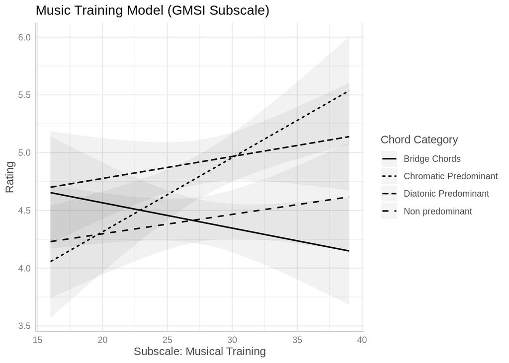

```r
##############################################################################
# Musical Training Sub Score
# Show is similar (not in manuscript)


ggpredict(musical_training_rm_f3,
          terms = c("f3_musical_training", "chord_family"),
          type = "fe") %>%
   plot(ci.style = "ribbon", colors = "bw", alpha = .05) +
   labs(x = "Subscale: Musical Training", y = "Rating",
        title = "Music Training Model (GMSI Subscale)")   -> rm_musical_plot_f3


rm_musical_plot_f3$labels$linetype <- "Chord Category"

rm_musical_plot_f3$data$group <- rm_musical_plot_f3$data$group %>% str_replace_all("bridge_chords", "Bridge Chords")
rm_musical_plot_f3$data$group <- rm_musical_plot_f3$data$group %>% str_replace_all("not_pd", "Non predominant")
rm_musical_plot_f3$data$group <- rm_musical_plot_f3$data$group %>% str_replace_all("common_pd", "Diatonic Predominant")
rm_musical_plot_f3$data$group <- rm_musical_plot_f3$data$group %>% str_replace_all("chromatic_pd", "Chromatic Predominant")

rm_musical_plot_f3
```

```r
collapsed_model %>%
  select(participant, f3_musical_training, i_have_had_formal_training_in_music_theory_for_years) %>%
  distinct() -> cor_muscials

cor.test(cor_muscials$f3_musical_training, cor_muscials$i_have_had_formal_training_in_music_theory_for_years)
```

```
##
##  Pearson's product-moment correlation
##
## data:  cor_muscials$f3_musical_training and cor_muscials$i_have_had_formal_training_in_music_theory_for_years
## t = 7.6883, df = 57, p-value = 0.0000000002268
## alternative hypothesis: true correlation is not equal to 0
## 95 percent confidence interval:
##  0.5596807 0.8197945
## sample estimates:
##      cor
## 0.713501
```

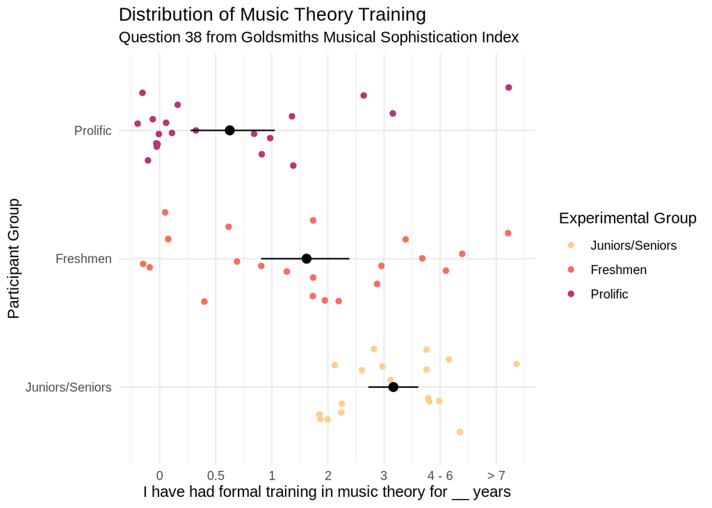

```r
# Descriptive Panel
model_data %>%
  mutate(experimental_group = str_to_title(experimental_group)) %>%
  mutate(experimental_group = factor(experimental_group, levels = c("Juniors/Seniors","Freshmen","Prolific"))) %>%
  select(experimental_group, i_have_had_formal_training_in_music_theory_for_years, participant) %>%
  distinct() %>%
  ggplot(aes(
    x = experimental_group, i_have_had_formal_training_in_music_theory_for_years,
    y = i_have_had_formal_training_in_music_theory_for_years,
    color = experimental_group, group = experimental_group)) +
  geom_jitter() +
  scale_y_continuous(breaks = seq(1,7,1),
                     labels = vexta) +
  stat_summary(fun = "mean", colour = "red", size = 2, geom = "point") +
  stat_summary(fun.data = "mean_cl_boot", colour = "black", size = .5 ) + # took down size
  coord_flip() +
  labs(title = "Distribution of Music Theory Training",
       subtitle = "Question 38 from Goldsmiths Musical Sophistication Index",
       x = "Participant Group",
       y = "I have had formal training in music theory for __ years", color = "Experimental Group") +
    scale_color_viridis(discrete = TRUE, option = "A", begin = .5, end = .9, direction = -1) +
  #scale_color_viridis(discrete = TRUE, option = "E", begin = .1, end = .9) + # added here for color, also needed to add aes groupings
  theme_minimal() -> descriptive_theory_plot

#descriptive_theory_plot$data$experimental_group <- descriptive_theory_plot$data$experimental_group %>% str_replace_all("Upperclass", "Juniors/Seniors")

descriptive_theory_plot
```

```r
#---------------------------------------------------------------------
```

### Music Feature + Training Model

```r
all_musical_indv_theory_model <- lmer(scale(rating) ~  scale(lerdhal_tension) +
                                      scale(parncut_roughness) + scale(semitone_voice_move) +
                                        as.character(rootmotion) + scale(number_tendency_tones4_6) +
                                        scale(i_have_had_formal_training_in_music_theory_for_years) +
                        (1+scale( i_have_had_formal_training_in_music_theory_for_years)|participant),
                                    data = model_data)


r.squaredGLMM(all_musical_indv_theory_model)
```

```
##             R2m       R2c
## [1,] 0.04690733 0.2534409
```

#### Figure for Musical Training Model

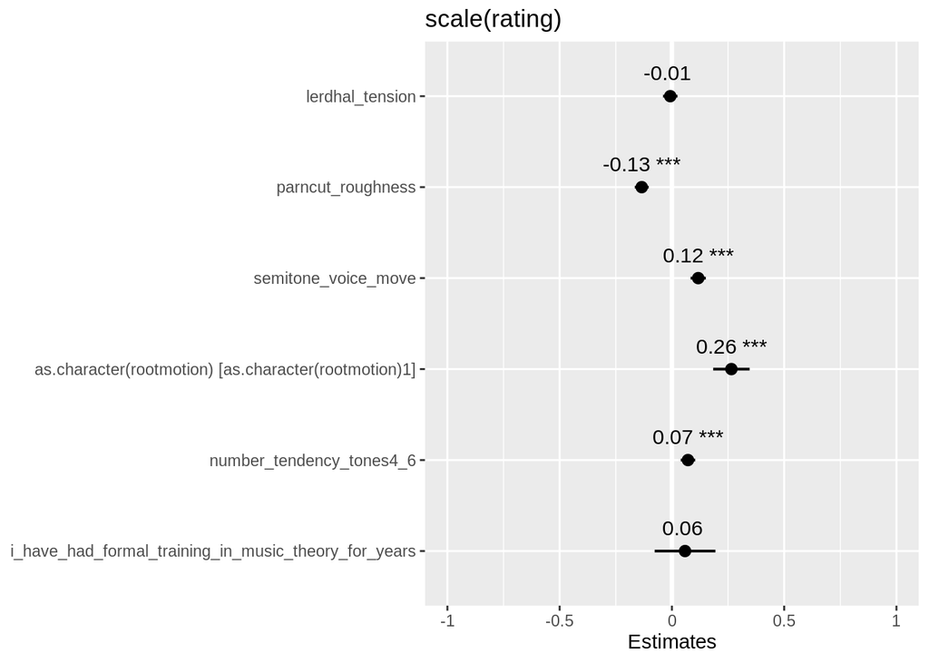

```r
(re.effects <- plot_model(all_musical_indv_theory_model, type = "est", show.values = TRUE,colors = c("black","black"),value.offset = .25))
```

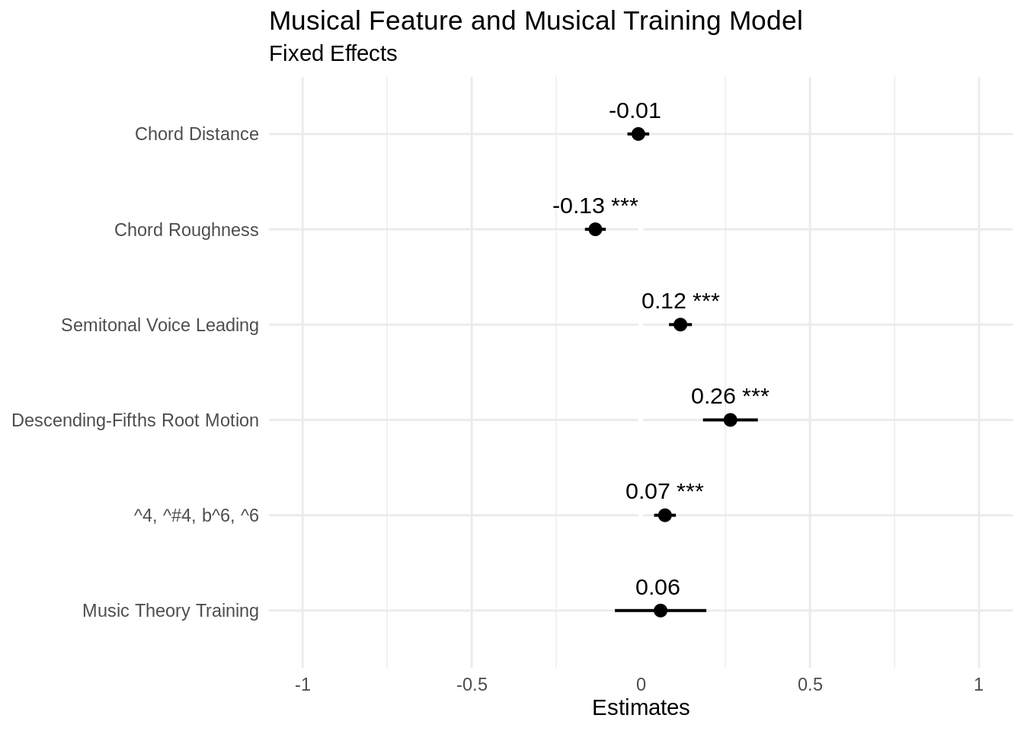

```r
levels(re.effects$data$term) <- c("Music Theory Training", "^4, ^#4, b^6, ^6" , "Descending-Fifths Root Motion",
                                  "Semitonal Voice Leading","Chord Roughness","Chord Distance")

re.effects +
  labs(title = "Musical Feature and Musical Training Model", subtitle = "Fixed Effects") +
  theme_minimal() -> model_3_figure

model_3_figure
```

```r
ggsave(plot = model_3_figure,
       filename = "img/Figures/Figure_Model_Three_fixed_effects_.png",
              height = 6, width = 9, units = "in", dpi = 300)
```

#### Combine to One Panel

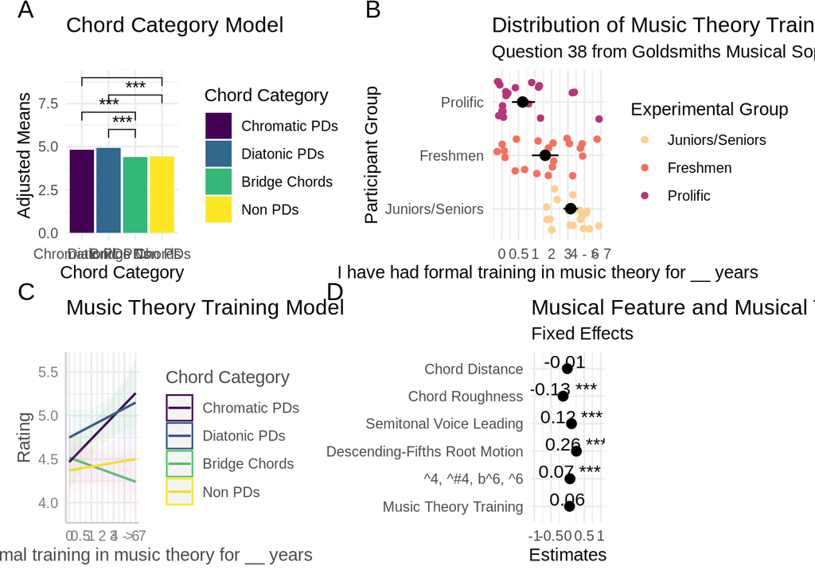

```r
(analysis_a_plot_1 + descriptive_theory_plot )/ (rm_musical_plot + model_3_figure) +
  plot_annotation( tag_levels = "A") &
    theme(plot.tag.position = c(0, 1),
        plot.tag = element_text(size = 15, hjust = 0, vjust = 0)) -> compound_plot

compound_plot
```

```r
ggsave(filename = "img/Figures/Figure2.png", height = 9, width = 13, units = "in", dpi = 300)

# ALL MODELS HERE
tab_model(chord_cat_rm, musical_training_rm, all_musical_indv_theory_model)
```

|  | mean rating |  |  | mean rating |  |  | scale(rating) |  |  |
| --- | --- | --- | --- | --- | --- | --- | --- | --- | --- |
| Predictors | Estimates | CI | p | Estimates | CI | p | Estimates | CI | p |
| (Intercept) | 4.40 | 4.20 – 4.59 | **<0.001** | 4.56 | 4.16 – 4.97 | **<0.001** | -0.04 | -0.14 – 0.07 | 0.522 |
| chord_family [chromatic_pd] | 0.42 | 0.32 – 0.52 | **<0.001** | -0.23 | -0.44 – -0.02 | **0.031** |  |  |  |
| chord_family [common_pd] | 0.53 | 0.43 – 0.63 | **<0.001** | 0.12 | -0.09 – 0.33 | 0.262 |  |  |  |
| chord_family [not_pd] | 0.03 | -0.07 – 0.13 | 0.536 | -0.21 | -0.43 – 0.00 | 0.050 |  |  |  |
| i_have_had_formal_training_in_music_theory_for_years |  |  |  | -0.05 | -0.14 – 0.05 | 0.354 |  |  |  |
| chord_family [chromatic_pd] * i_have_had_formal_training_in_music_theory_for_years |  |  |  | 0.18 | 0.13 – 0.23 | **<0.001** |  |  |  |
| chord_family [common_pd] * i_have_had_formal_training_in_music_theory_for_years |  |  |  | 0.11 | 0.06 – 0.16 | **<0.001** |  |  |  |
| chord_family [not_pd] * i_have_had_formal_training_in_music_theory_for_years |  |  |  | 0.07 | 0.02 – 0.12 | **0.010** |  |  |  |
| lerdhal_tension |  |  |  |  |  |  | -0.01 | -0.04 – 0.02 | 0.655 |
| parncut_roughness |  |  |  |  |  |  | -0.13 | -0.17 – -0.10 | **<0.001** |
| semitone_voice_move |  |  |  |  |  |  | 0.12 | 0.08 – 0.15 | **<0.001** |
| as.character(rootmotion) [as.character(rootmotion)1] |  |  |  |  |  |  | 0.26 | 0.18 – 0.35 | **<0.001** |
| number_tendency_tones4_6 |  |  |  |  |  |  | 0.07 | 0.04 – 0.10 | **<0.001** |
| i_have_had_formal_training_in_music_theory_for_years |  |  |  |  |  |  | 0.06 | -0.08 – 0.19 | 0.397 |
| Random Effects |  |  |  |  |  |  |  |  |  |
| σ<sup>2</sup> | 1.20 |  |  | 1.19 |  |  | 0.76 |  |  |
| τ<sub>00</sub> | 0.49 <sub>participant</sub> |  |  | 0.49 <sub>participant</sub> |  |  | 0.09 <sub>participant</sub> |  |  |
| τ<sub>11</sub> |  |  |  |  |  |  | 0.12 <sub>participant.scale(i_have_had_formal_training_in_music_theory_for_years)</sub> |  |  |
| ρ<sub>01</sub> |  |  |  |  |  |  | -0.20 <sub>participant</sub> |  |  |
| ICC | 0.29 |  |  | 0.29 |  |  | 0.22 |  |  |
| N | 59 <sub>participant</sub> |  |  | 59 <sub>participant</sub> |  |  | 59 <sub>participant</sub> |  |  |
| Observations | 3658 |  |  | 3658 |  |  | 3658 |  |  |
| Marginal R<sup>2</sup> / Conditional R<sup>2</sup> | 0.031 / 0.310 |  |  | 0.045 / 0.323 |  |  | 0.047 / 0.253 |  |  |

## Unsupervised Analyses

The next two sections show code used for the PCA and HCA.

```r
# Re-Import Tables
# Get only rating data
attraction_ratings <- response_data %>%
  dplyr::select(I:`viio7/V`, group, participant)

# Demographic Data
gmsi <- read_csv("tidy_tables/gmsi_table.csv")
gmsi <- janitor::clean_names(gmsi)
gmsi <- gmsi %>%
  rename(experimental_group = group,
         participant = participant_no)

gmsi %>%
  dplyr::select(participant, i_have_had_formal_training_in_music_theory_for_years) -> gmsi_2

attraction_ratings <- attraction_ratings %>%
  left_join(gmsi_2)
chord_stimuli_data <- read_csv("tidy_tables/chord_experiment_stimuli_data.csv")
chord_stimuli_data <- chord_stimuli_data %>%
  rename(chord = chord_symbol,
         chord_family = group)
```

The object `attraction_ratings` now has all the ratings of the chords and the group identifier from where the rating came from.

Next, we prep and run the PCA on this data. Experimental group is saved to be an identifier.

```r
# Make Exploratory Plot
pca_rec <- recipe(~., data = attraction_ratings ) %>%
    update_role(group, participant, i_have_had_formal_training_in_music_theory_for_years, new_role = "id") %>%
  step_normalize(all_predictors()) %>%
  step_pca(all_predictors())

pca_prep <- prep(pca_rec)

pca_prep
```

```
## Data Recipe
##
## Inputs:
##
##       role #variables
##         id          3
##  predictor         31
##
## Training data contained 118 data points and no missing data.
##
## Operations:
##
## Centering and scaling for I, i, I7, i7, viio, viiø7, viio7, iii, ... [trained]
## PCA extraction with I, i, I7, i7, viio, viiø7, viio7, iii, III, ... [trained]
```

```r
tidied_pca <- tidy(pca_prep, 2)

chord_stimuli_data_table <- chord_stimuli_data %>%
  rename(terms = chord)

tidied_pca %>%
  left_join(chord_stimuli_data_table) -> tidied_pca2
```

Now we have scores for every single chord on every single dimension.

Want to know if our PCA was helpful at all first.

```r
# Extract PCA Variance
sdev <- pca_prep$steps[[2]]$res$sdev

percent_variation <- sdev^2 / sum(sdev^2)

sum(percent_variation[1:3])
```

```
## [1] 0.4669943
```

```r
sum(percent_variation[1])
```

```
## [1] 0.2675672
```

```r
sum(percent_variation[2])
```

```
## [1] 0.1151911
```

```r
sum(percent_variation[3])
```

```
## [1] 0.084236
```

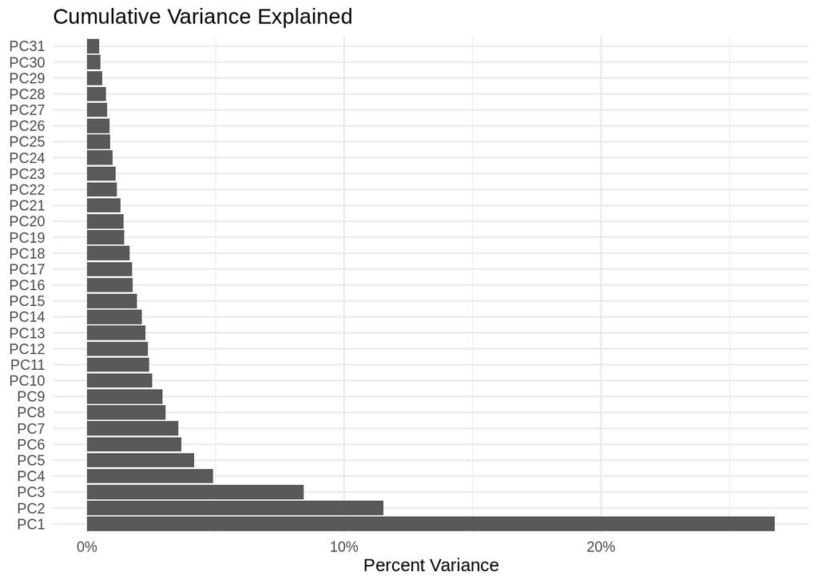

```r
tibble(
  component = unique(tidied_pca$component),
  percent_var = percent_variation ## use cumsum() to find cumulative, if you prefer
) %>%
  mutate(component = fct_inorder(component)) %>%
  ggplot(aes(component, percent_var)) +
  geom_col() +
  scale_y_continuous(labels = scales::percent_format()) +
  labs(x = NULL, y = "Percent Variance",
       title = "Cumulative Variance Explained") +
  theme_minimal() +
  coord_flip() -> var_explained_plot

var_explained_plot
```

```r
ggsave(filename = "img/Figures/Figure_Variation_Explained.png",
       height = 6, width = 9, dpi = 300, plot = var_explained_plot)
```

Next we plot the first five principle components with all items.

Main take aways from plot

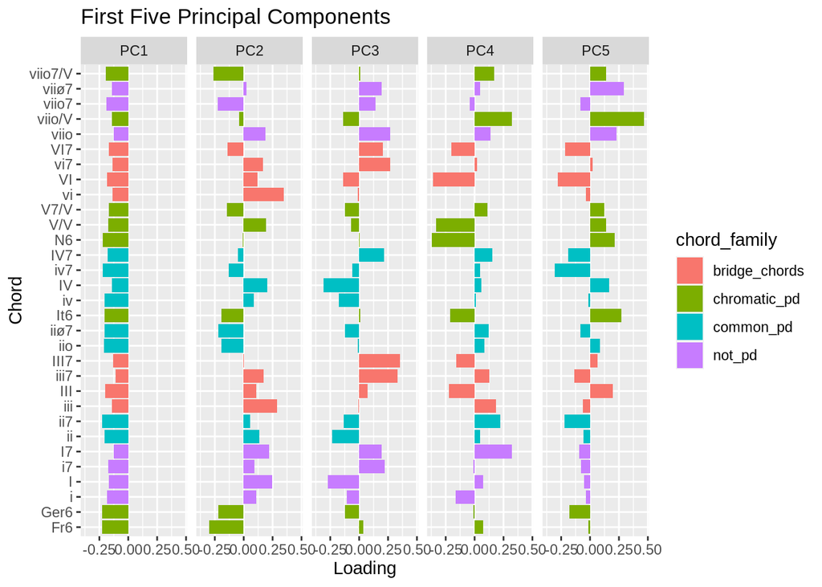

```r
# PLOTS HERE NOT IN MANUSCRIPT
# EXCLUDE
tidied_pca2 %>%
  filter(component %in% paste0("PC", 1:5)) %>%
  mutate(component = fct_inorder(component)) %>%
  ggplot(aes(value, terms, fill = chord_family)) +
  geom_col() +
  facet_wrap(~component, nrow = 1) +
  labs(y = "Chord", x = "Loading", title = "First Five Principal Components") -> pc15

pc15
```

```r
ggsave(filename = "img/Figures/Figure_PC1to5.png", height = 6, width = 9, dpi = 300, plot = pc15)
```

- PC1 is Pre Dominant Attraction

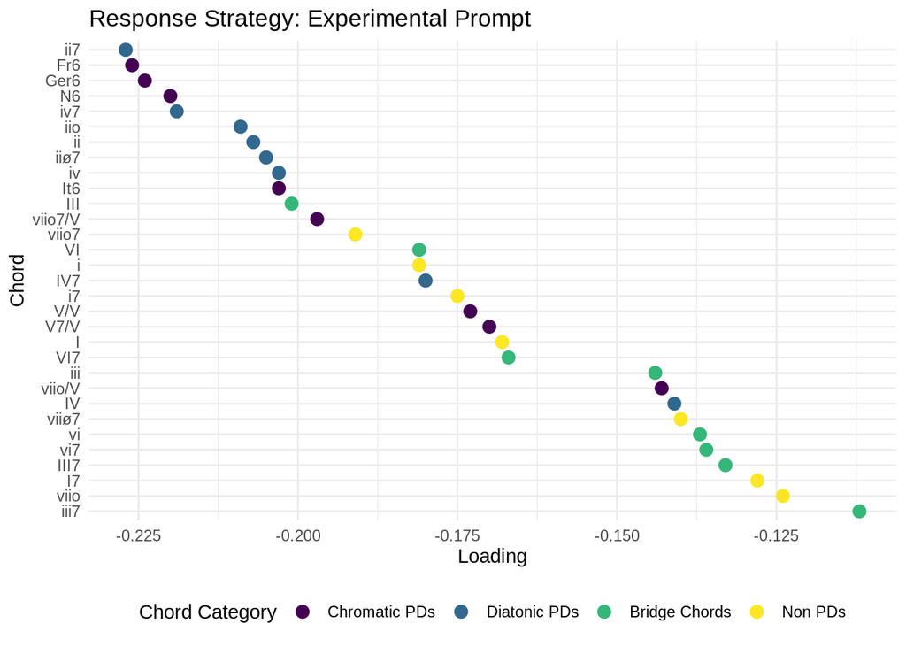

```r
tidied_pca2 %>%
  filter(component %in% paste0("PC", 1)) %>%
  mutate(component = fct_inorder(component)) %>%
  mutate(value = round(value, 3)) %>%
  mutate(chord_family = str_replace_all(chord_family, "_"," ")) %>%
  mutate(chord_family = str_to_title(chord_family)) %>%
  mutate(chord_family = str_replace_all(chord_family,"Pd","PDs")) %>%
  mutate(chord_family = str_replace_all(chord_family,"Not","Non")) %>%
  mutate(chord_family = str_replace_all(chord_family,"Common","Diatonic")) %>%
  mutate(chord_family = factor(chord_family, levels = c("Chromatic PDs","Diatonic PDs","Bridge Chords", "Non PDs"))) %>%
  ggplot(aes(x = value, y = reorder(terms, abs(value)))) +
  geom_point(aes(color = chord_family), size = 3) + # swapped from shape
  theme_minimal() +
  scale_color_viridis(option = "D", discrete = TRUE) +
  theme(legend.position="bottom") +
  labs(y = "Chord", x = "Loading",
       title = "Response Strategy: Experimental Prompt", shape = "Chord Category",
       color = "Chord Category") -> pc1

# chromatic - purple
# diantoinc - blue
# bridge -green
# nonpd - yellow

pc1
```

```r
ggsave(filename = "img/Figures/PC1.png",
       height = 9, width = 5, dpi = 300, plot = pc1)
```

- PC2 is sensitivy to training, more evident through next chart

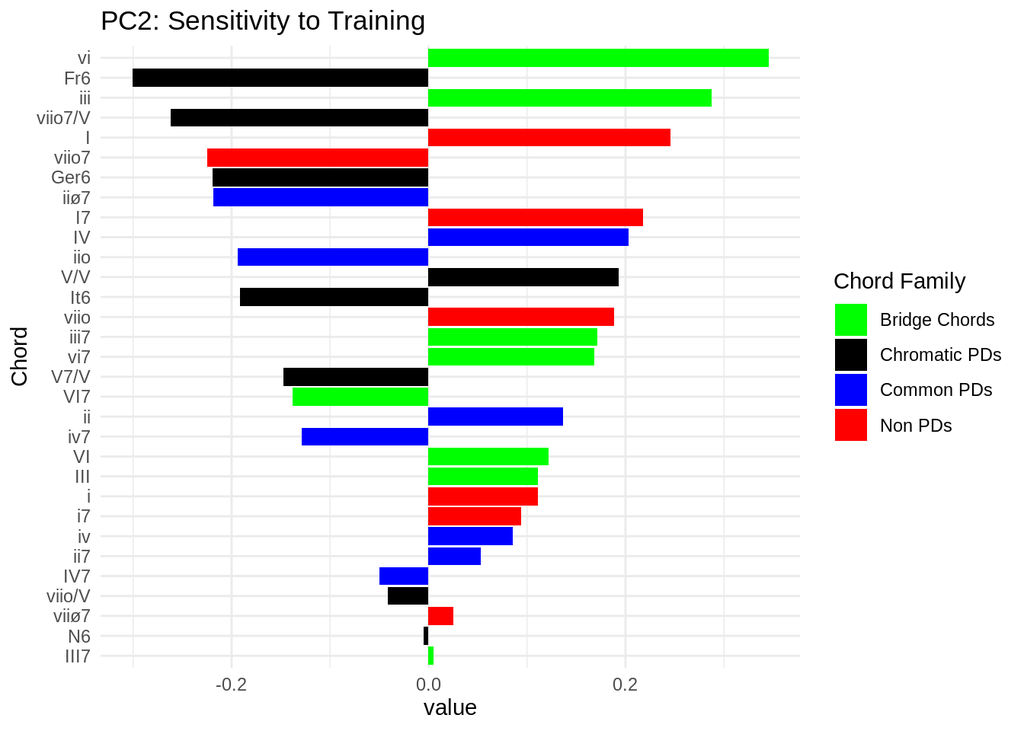

```r
tidied_pca2 %>%
  filter(component %in% paste0("PC", 2)) %>%
  mutate(component = fct_inorder(component)) %>%
  ggplot(aes(x = value, y = reorder(terms, abs(value)), fill = chord_family)) +
  geom_col() +
  theme_minimal() +
  scale_fill_manual(labels = c("Bridge Chords","Chromatic PDs","Common PDs","Non PDs"),
                    values = c("green","black","blue","red")) +
  labs(y = "Chord", title = "PC2: Sensitivity to Training", fill = "Chord Family") -> pc2

pc2
```

```r
ggsave(filename = "img/Figures/PC2.png", height = 6, width = 9, dpi = 300, plot = pc2)
```

Here we use loadings on each rating, plot PC1 vs PC2

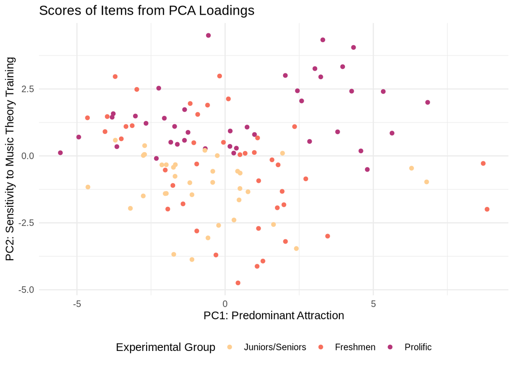

```r
# PANEL 2
juice(pca_prep) %>%
  mutate(group = str_replace_all(group, "upperclass","Juniors/Seniors")) %>%
  mutate(group = str_replace_all(group, "freshman","freshmen")) %>%
  mutate(group = str_to_title(group)) %>%
  mutate(`Experimental Group` = str_to_title(group)) %>%
  mutate(`Experimental Group` = factor(`Experimental Group`, levels = c("Juniors/Seniors","Freshmen","Prolific"))) %>%
  ggplot(aes(PC1, PC2,
            # shape = `Experimental Group`,
             color = `Experimental Group`)) +
  geom_point(alpha = 1) +
  scale_shape_manual(values=c( 8, 13, 4))+
  scale_color_viridis(discrete = TRUE, option = "A", begin = .5, end = .9, direction = -1) +
  theme_minimal() +
  theme(legend.position="bottom") +
  labs(title = "Scores of Items from PCA Loadings",
       x = "PC1: Predominant Attraction",
       y = "PC2: Sensitivity to Music Theory Training",
       shape = "Participant Group") -> pc1vpc2

pc1vpc2
```

```r
ggsave(filename = "img/Figures/PC1vsPC2.png", height = 6, width = 9, dpi = 300, plot = pc1vpc2)
```

#### Panel 3 for Manuscript

```r
# Make Panel
library(patchwork)
(pc1 + (pc1vpc2)) + plot_annotation(tag_levels = "A") -> pca_panel

library(cowplot)
cowplot::plot_grid(pc1, pc1vpc2,labels = "AUTO", label_size = 24) -> pca_panel_2


ggsave(plot = pca_panel, filename = "img/Figures/Figure3.png", height = 9, width = 12, dpi = 300)
ggsave(plot = pca_panel_2, filename = "img/Figures/Figure3cow.png", height = 9, width = 12, dpi = 300)
```

```r
# Old Exploratory Plots, Not in Manuscript
juice(pca_prep) %>%
  ggplot(aes(PC1, PC3, color = group)) +
  geom_point(alpha = 0.7, size = 2) +
  labs() -> pc1vpc3

ggsave(filename = "img/unsupervised/pc1vpc3.png", height = 6, width = 9, dpi = 300, plot = pc1vpc3)

juice(pca_prep) %>%
  ggplot(aes(PC2, PC3, color = group)) +
  geom_point(alpha = 0.7, size = 2) +
  labs() -> pc2vpc3

ggsave(filename = "img/unsupervised/pc2vpc3.png", height = 6, width = 9, dpi = 300, plot = pc2vpc3)
```

More Exploration, not included

```r
# Correlation with general average
# tidied_pca2 %>%
#   filter(component == "PC1") %>%
#   dplyr::select(terms, value) %>%
#   rename(chord = terms) -> pca_terms
#
#
# feature_model_data %>%
#   dplyr::select(mean_chord_ratings, chord) %>%
#   left_join(pca_terms)-> cor_pca
#
# cor_pca %>%
#   ggplot(aes(x = value, y = mean_chord_ratings, label = chord)) +
#   geom_point() +
#   geom_text(nudge_y = .1) +
#   geom_smooth()
#
# cor.test(cor_pca$mean_chord_ratings, cor_pca$value)
```

### HCA

```r
chord_stimuli_data <- read_csv("tidy_tables/chord_experiment_stimuli_data.csv")
chord_stimuli_data <- chord_stimuli_data %>%
  rename(chord = chord_symbol,
         chord_family = group)

# Chord Features
chord_features <- read_csv("tidy_tables/chord_features.csv")
chord_features <- janitor::clean_names(chord_features)

chord_features <- chord_features %>%
  separate(col = stimuli, into = c("chord_id","temp"), "\\.") %>%
  separate(col = temp, into = c("chord","notes"), sep = "\\:") %>%
  mutate(chord = str_trim(chord)) %>%
  mutate(notes = str_trim(notes))

chord_features %>%
  select(parncut_roughness:number_4_b6) -> cluster_features

rownames(cluster_features) <- chord_features$chord
```

```r
cluster_features %>% scale() -> scaled_cluster_features

dist_cluster <- dist(scaled_cluster_features)

dist_cluster_object <- hclust(dist_cluster, method = "complete")

par(mfrow=c(1,1))

jpeg("img/Figures/Figure4.jpeg", height = 500, width = 900)

plot(dist_cluster_object , xlab="", sub="", cex=1.5, main = "HCA of Chord Features")
dev.off()
```

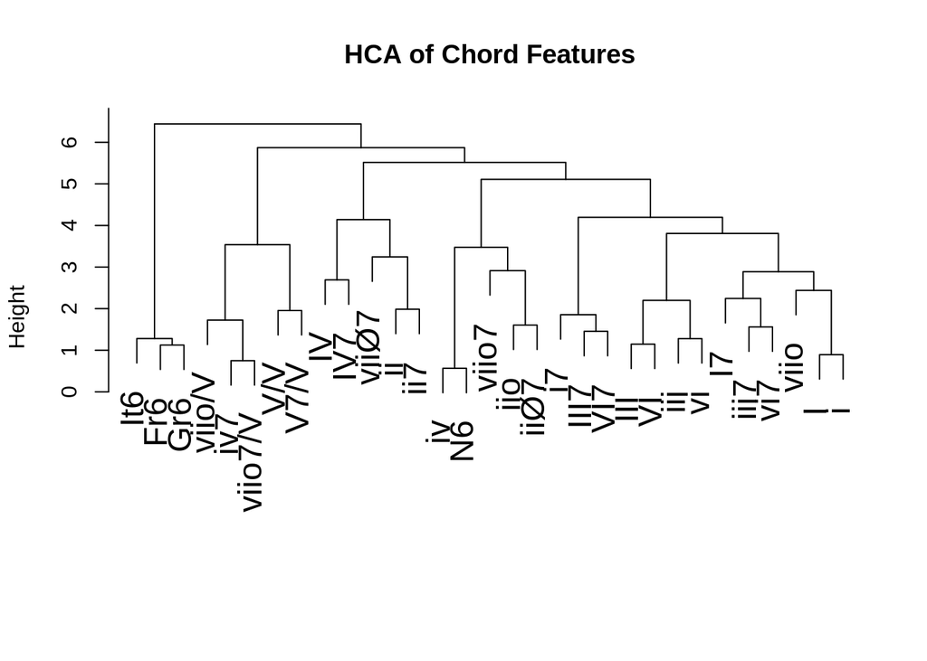

```r
plot(dist_cluster_object , xlab="", sub="", cex=1.5, main = "HCA of Chord Features")
```

```r
# ADD COLOR =====================================================================
#install.packages("dendextend")
library(dendextend)
# dont judge me for doing this manually
#scale_color_manual(values = c("#55C667FF","#440154FF","#39568CFF","#FDE725FF"))

# chromatic - purple
# diantoinc - blue
# bridge -green
# nonpd - yellow

helper <- data.frame(color = c("yellow","green","blue","purple"),
            chord_family = c("not_pd","bridge_chords","common_pd","chromatic_pd") )

chord_stimuli_data %>%
  select(chord, chord_family) %>%
  left_join(helper) %>%
  print(n = 100)
```

```
## # A tibble: 31 x 3
##    chord   chord_family  color
##    <chr>   <chr>         <chr>
##  1 I       not_pd        yellow
##  2 i       not_pd        yellow
##  3 I7      not_pd        yellow
##  4 i7      not_pd        yellow
##  5 viio    not_pd        yellow
##  6 viiø7   not_pd        yellow
##  7 viio7   not_pd        yellow
##  8 iii     bridge_chords green
##  9 III     bridge_chords green
## 10 iii7    bridge_chords green
## 11 III7    bridge_chords green
## 12 vi      bridge_chords green
```

[output cut: 19 more lines]

```r
jpeg("img/Figures/Figure4_color.jpeg", height = 400, width = 800)


dist_cluster_object %>%
  as.dendrogram %>%
  set("labels_col", c(
    "#440154FF",  # Purple
    "#440154FF",  # Purple
    "#440154FF",  # Purple
    "#440154FF",  # Purple (Viio/V)
    "#39568CFF",  # Blue (iv7)
    "#440154FF",  # Purple (viio7/V)
    "#440154FF",  # Purple V/V
    "#440154FF",  # Purple V7/V
    "#39568CFF",  # Blue IV
    "#39568CFF",  # Blue IV7

    "#FDE725FF",  # vii full dim 7
    "#39568CFF",  # Blue
    "#39568CFF",  # Blue
    "#39568CFF",  # Blue
    "#440154FF",  # Purple (N6)

    "#FDE725FF",  # yellow (vii07)
    "#39568CFF",  # Blue
    "#39568CFF",  # Blue
    "#FDE725FF",  # #55C667FF (i7)
    "#55C667FF",  # III7
    "#55C667FF",  # VI7
    "#55C667FF",  # III
    "#55C667FF",  # VI
    "#55C667FF",  #
    "#55C667FF",
    "#FDE725FF",  # #55C667FF (I7)
    "#55C667FF",  # #55C667FF
    "#55C667FF",  # #55C667FF
    "#FDE725FF",
    "#FDE725FF",
    "#FDE725FF"

    )) %>%
  set("labels_cex", 1.5) %>%
  plot(main = "HCA Chord Features")

legend("topright",
     legend = c("Chromatic PDs" , "Diatonic PDs" , "Bridge Chords" , "Non PDs"),
     col = c(
           "#440154FF",  # Purple
              "#39568CFF",  # Blue
    "#55C667FF",
    "#FDE725FF"  # Yellow
    ),
     pch = c(20), bty = "n", cex = 1.5 ,
     text.col = "black", horiz = FALSE, inset = c(0, 0))

dev.off()
```

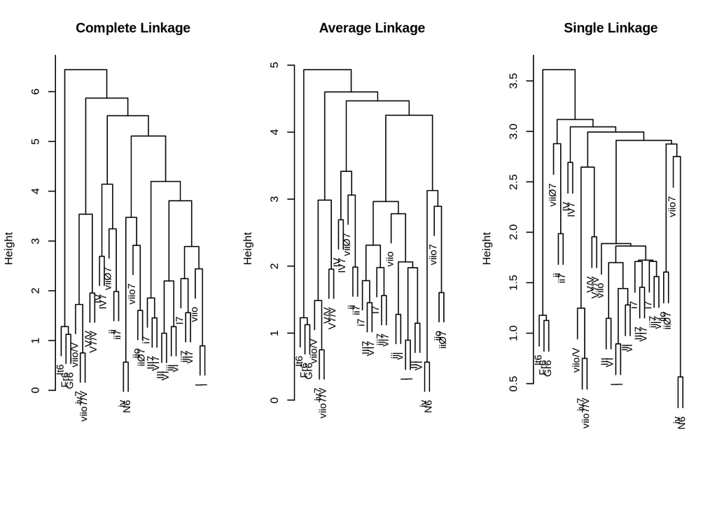

```r
#=================================================================================


# Linage does not seem to affect too much in terms of general categories
dist_cluster_object_complete <- hclust(dist_cluster,method = "complete")
dist_cluster_object_average <- hclust(dist_cluster,method = "average")
dist_cluster_object_single <- hclust(dist_cluster, method = "single")

par(mfrow=c(1,3))

plot(dist_cluster_object_complete ,main="Complete Linkage", xlab="", sub="",
cex=.9)

plot(dist_cluster_object_average , main="Average Linkage", xlab="", sub="",
cex=.9)

plot(dist_cluster_object_single, main="Single Linkage", xlab="", sub="",
cex=.9)
```